# Curso II – SISSA

Ejercicio 5

## Esquema

Este tutorial está compuesto por un ejercicio:

- Fusión de productos de precipitación con estaciones utilizando el paquete [**RFmerge**](https://github.com/hzambran/RFmerge).

Después de completar este tutorial, podrás fusionar productos de precipitación con estaciones utilizando el paquete **RFmerge**.

### Objetivo de la tarea

Para este ejercicio, los estudiantes deberán:

1. Fusionar CHIRPSv2, PERSIANN-CDR, y un modelo digital de elevacion (SRTMv4.1) con estaciones para producir rasters de precipitación diaria sobre Valparaiso, Chile.

### Material

En los datos de este ejercicio hay cinco carpetas:

1. P_products: Esta carpeta contiene 2 archivos *GeoTiff* con valores diarios de precipitación para enero - Agosto de 1983: *CHIRPS5km.tif* y *PERSIANNcdr5km.tif*.
2. DEM: Carpeta con el modelo digital de elevación SRTMv4.1.
3. Shapefile: Carpeta que contiene el shapefile de Valparaiso.
4. Statios_data: Carpeta que contiene las series temporales de precipitación (*Timeseries.zoo*) y sus metadatos (*Metadata.csv*).
5. Output: Carpeta vacia para guardar los resultados.

Para fusionar los productos de precipitación seleccionados (CHIRPSv2 y PERSIANN-CDR) con estaciones in situ en Valparaíso, Chile, seguiremos los siguientes pasos:

**Paso 1**: Cargar los paquetes necesarios para trabajar con las estaciones:

```r
library(zoo)
library(terra)
```

El paquete **RFmerge** se puede instalar desde Github:

```r
remotes::install_github('hzambran/RFmerge')
library(RFmerge)
```

**Paso 2**: Cargar los datos de las estaciones y el shapefile del área de estudio. Para esto, almacenaremos las rutas de los archivos:

```r
observations <- 'C:/Users/Data/Timeseries.zoo'
metadata     <- 'C:/Users/Data/Metadata.csv'
shape        <- 'C:/Users/Data/Valparaiso.shp'
```

En este paso, estamos especificando las rutas de los archivos de datos de las estaciones y del shapefile del área de estudio. Asegúrate de proporcionar las rutas correctas a tus archivos correspondientes.

Podemos utilizar la función **read.zoo** del paquete **zoo** para importar las series temporales, la función **read.csv** para importar los metadatos y la función **vect** del paquete **terra** para importar el shapefile.

```r
observations <- read.zoo(observations, header = TRUE)
metadata     <- read.csv(metadata)
shape        <- vect(shape)
```

**Paso 3**: Ahora podemos cargar los datos diarios de los productos de precipitación y el modelo digital de elevación. Para esto, almacenaremos las rutas de los archivos correspondientes.

```r
chirps        <- 'C:/Users/Data/P_products/CHIRPS5km.tif'
persiann_cdr  <- 'C:/Users/Data/P_products/PERSIANNcdr5km.tif'
dem           <- 'C:/Users/Data/DEM/ValparaisoDEM5km.tif'
```

Podemos utilizar la función **rast** del paquete **terra** para importar los productos de precipitación (archivos multibanda) y el DEM.

```r
chirps        <- rast(chirps)
persiann_cdr  <- rast(persiann_cdr)
dem           <- rast(dem)
print(chirps)
```

```
## class       : SpatRaster
## dimensions  : 40, 38, 243  (nrow, ncol, nlyr)
## resolution  : 0.05, 0.05  (x, y)
## extent      : -71.85, -69.95, -34, -32  (xmin, xmax, ymin, ymax)
## coord. ref. : lon/lat WGS 84 (EPSG:4326)
## source      : CHIRPS5km.tif
## names       : CHIRPS5km_1, CHIRPS5km_2, CHIRPS5km_3, CHIRPS5km_4, CHIRPS5km_5, CHIRPS5km_6, ...
```

```r
print(persiann_cdr)
```

```
## class       : SpatRaster
## dimensions  : 40, 38, 243  (nrow, ncol, nlyr)
## resolution  : 0.05, 0.05  (x, y)
## extent      : -71.85, -69.95, -34, -32  (xmin, xmax, ymin, ymax)
## coord. ref. : lon/lat WGS 84 (EPSG:4326)
## source      : PERSIANNcdr5km.tif
## names       : PERSI~5km_1, PERSI~5km_2, PERSI~5km_3, PERSI~5km_4, PERSI~5km_5, PERSI~5km_6, ...
```

```r
print(dem)
```

```
## class       : SpatRaster
## dimensions  : 40, 38, 1  (nrow, ncol, nlyr)
## resolution  : 0.05, 0.05  (x, y)
## extent      : -71.85, -69.95, -34, -32  (xmin, xmax, ymin, ymax)
## coord. ref. : lon/lat WGS 84 (EPSG:4326)
## source      : ValparaisoDEM5km.tif
## name        : ValparaisoDEM5km
## min value   :          11.4891
## max value   :        5123.8408
```

Los dos archivos geotiff multibanda proporcionados no almacenan la fecha de la estimación de precipitación. Por lo tanto, antes de realizar cualquier análisis exploratorio, es necesario asignar nombres significativos a cada banda. Esto nos permitirá tener una mejor idea de las fechas asociadas a cada capa y facilitará el análisis posterior de los datos.

```r
ldates <- hydroTSM::dip("1983-01-01", "1983-08-31")
names(chirps)       <- ldates
names(persiann_cdr) <- ldates
```

A continuación, queremos visualizar las primeras y últimas seis filas de los metadatos espaciales:

```r
head(metadata)
```

```
##       Code      lon      lat            NOM_REG  NOM_PROV COD_COM     NOM_COM
## 1 P5101005 -70.8000 -32.0836 Regin de Valparaso Los Andes    5304 San Esteban
## 2 P5111002 -71.0300 -32.1567 Regin de Valparaso Los Andes    5304 San Esteban
## 3 P5101006 -70.7833 -32.1836 Regin de Valparaso Los Andes    5304 San Esteban
## 4 P5100006 -70.7839 -32.2261 Regin de Valparaso Los Andes    5304 San Esteban
## 5 P5100005 -70.7100 -32.2286 Regin de Valparaso Los Andes    5304 San Esteban
## 6 P5111001 -71.1386 -32.2528 Regin de Valparaso Los Andes    5304 San Esteban
```

```r
tail(metadata)
```

```
##        Code      lon      lat            NOM_REG  NOM_PROV COD_COM     NOM_COM
## 29 P5427006 -71.2144 -33.0986 Regin de Valparaso Los Andes    5304 San Esteban
## 30 P5510002 -71.5553 -33.1450 Regin de Valparaso Los Andes    5304 San Esteban
## 31 P5741002 -71.1467 -33.1686 Regin de Valparaso Los Andes    5304 San Esteban
## 32 P5530002 -71.6250 -33.5747 Regin de Valparaso Los Andes    5304 San Esteban
## 33 P5748003 -71.5106 -33.6344 Regin de Valparaso Los Andes    5304 San Esteban
## 34  P330030 -71.6142 -33.6550 Regin de Valparaso Los Andes    5304 San Esteban
```

Ahora podemos graficar la serie temporal diaria de precipitación para la primera estación (código: P5101005).

```r
main <- paste("Precipitación diaria para la estación", metadata$Code[1])
ylab <- "Precipitación [mm]"
x_ts <- observations[,1]
#plot(x.ts, main=main, ylab= ylab, col="blue")
hydroTSM::hydroplot(x_ts, pfreq="o", main=main, ylab= ylab)
```

```
## [Note: pfreq='o' => ptype has been changed to 'ts']
```

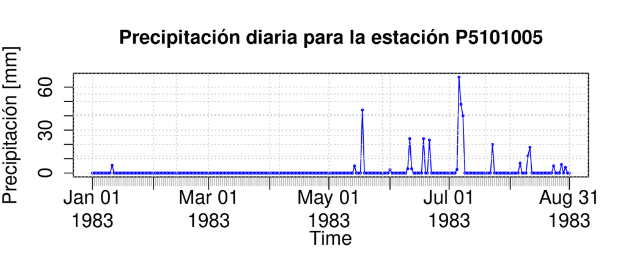

```r
grid()
```

Podemos graficar las estimaciones de precipitación acumulada para los primeros ocho meses de 1983 de CHIRPS y PERSIANN-CDR, y superponer los límites del área de estudio:

```r
chirps_total   <- sum(chirps, na.rm= FALSE)
persiann_total <- sum(persiann_cdr, na.rm= FALSE)
```

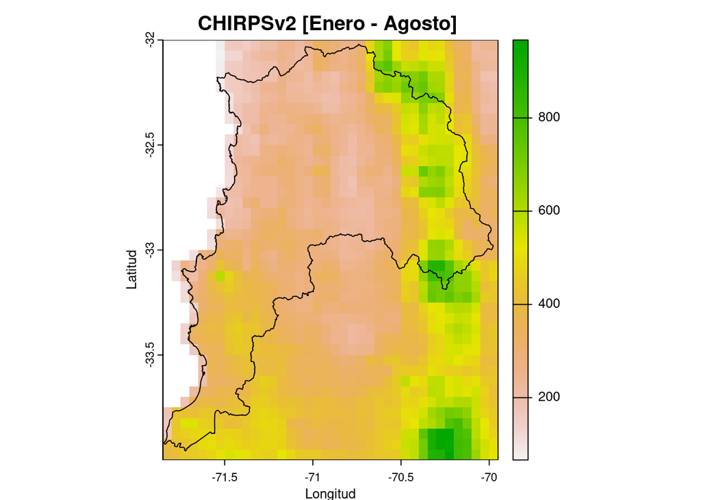

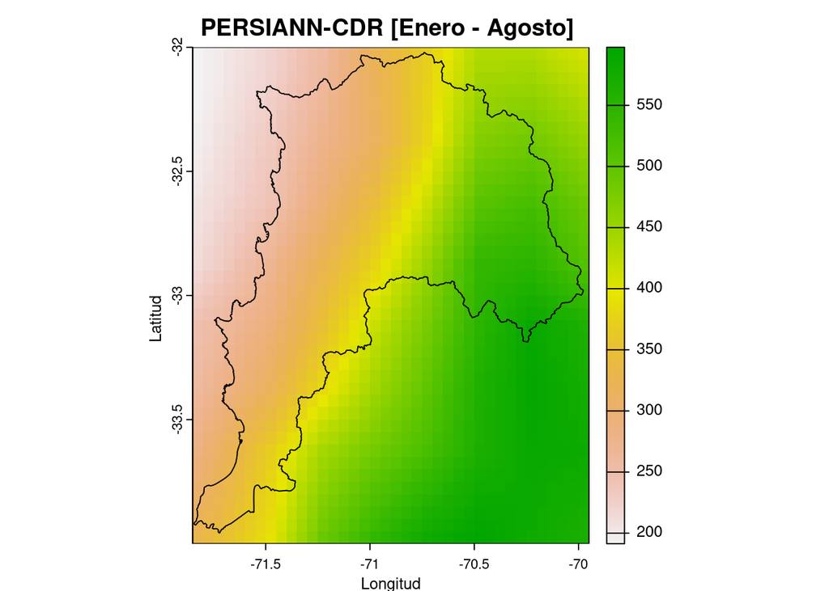

```r
plot(chirps_total, main = "CHIRPSv2 [Enero - Agosto] ", xlab = "Longitud", ylab = "Latitud")
lines(shape)

plot(persiann_total, main = "PERSIANN-CDR [Enero - Agosto] ", xlab = "Longitud", ylab = "Latitud")
lines(shape)
```

**Paso 4**: Convertir el objeto metadata en un objeto espacial. Para esto, lo transformatemos en un SpatVect utilizando los campos de latitud y longitud, almacenados en las columnas lat y lon:

```r
stations <- vect(metadata, geom = c('lon', 'lat'), crs = 'epsg:4326')
print(stations)
```

```
##  class       : SpatVector
##  geometry    : points
##  dimensions  : 34, 5  (geometries, attributes)
##  extent      : -71.625, -70.4719, -33.655, -32.0836  (xmin, xmax, ymin, ymax)
##  coord. ref. : lon/lat WGS 84 (EPSG:4326)
##  names       :     Code            NOM_REG  NOM_PROV COD_COM     NOM_COM
##  type        :    <chr>              <chr>     <chr>   <int>       <chr>
##  values      : P5101005 Regin de Valparaso Los Andes    5304 San Esteban
##                P5111002 Regin de Valparaso Los Andes    5304 San Esteban
##                P5101006 Regin de Valparaso Los Andes    5304 San Esteban
```

Ahora podemos graficar el DEM con las ubicaciones de las estaciones pluviométricas que se utilizarán en el cálculo de RF-MEP, y superponiendo los límites del área de estudio y las estaciones:

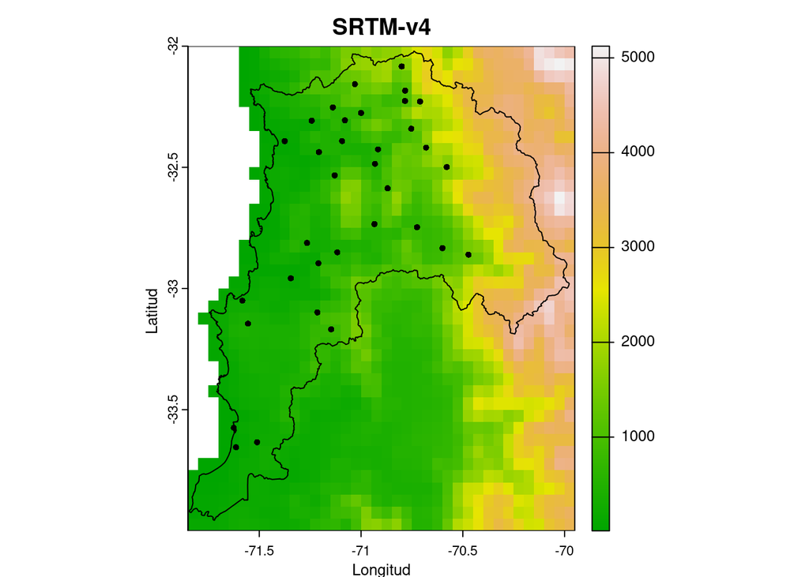

```r
plot(dem, main="SRTM-v4", xlab="Longitud", ylab="Latitud", col=terrain.colors(255))
lines(shape)
points(stations, pch = 16, col="black", add = TRUE)
```

**Paso 5**: Queremos producir un producto fusionado de precipitación desde el 1 de enero hasta el 31 de agosto de 1983 (243 días). Por lo tanto revisaremos la longitud de los productos.

```r
nlyr(chirps)
```

```
## [1] 243
```

```r
nlyr(chirps) == nlyr(persiann_cdr)
```

```
## [1] TRUE
```

```r
nlyr(chirps) == nrow(observations)
```

```
## [1] TRUE
```

Además, revisaremos la extensión espacial y la resolución espacial de los productos.

```r
ext(chirps) == ext(persiann_cdr)
```

```
## [1] TRUE
```

```r
res(chirps) == res(persiann_cdr)
```

```
## [1] TRUE TRUE
```

**Paso 6**: Ahora vamos a fusionar los productos de precipitación, el DEM y los datos de las estaciones. Para esto, prepararemos una lista de covariables.

```r
covariates <- list(chirps=chirps, persiann_cdr=persiann_cdr, dem=dem)
```

Si deseas que los archivos resultantes fusionados se escriban en disco, debes definir el directorio de salida (*drty.out*) antes de ejecutar **RFmerge**. Luego, puedes ejecutar la función **RFmerge** de la siguiente manera:

```r
drty_out <- file.path("C:/Data/Merging/Output/")
```

```r
rfmep <- RFmerge(x=observations, metadata=metadata, cov=covariates,
                 id="Code", lat="lat", lon="lon", mask=shape,
                 training=0.8, write2disk=TRUE, drty.out=drty_out)
```

Si *write2disk=TRUE*, los siguientes archivos de salida se almacenarán en el directorio drty.out definido por el usuario:

- 1. las estaciones de medición de precipitación utilizadas como conjuntos de datos de entrenamiento y evaluación; y
- 2. el producto fusionado final (archivos GeoTiff individuales).

Los objetos resultantes mencionados anteriormente se almacenarán dentro de **drty.out** de la siguiente manera:

- Ground_based_data/Training/: datos de series temporales y metadatos utilizados para entrenar RF-MEP como un archivo zoo (Training_ts.txt) y un archivo de texto (Training_metadata.txt), respectivamente.

Los objetos resultantes mencionados anteriormente se almacenarán dentro de **drty.out** de la siguiente manera:

- Ground_based_data/Evaluation/: Este directorio almacenará las series temporales y metadatos que no se utilizaron para entrenar el modelo Random Forest, pero que están disponibles para evaluar el rendimiento de los resultados en un conjunto de datos de evaluación independiente. Los archivos Evaluation_ts.txt y Evaluation_metadata.txt se almacenan como archivos zoo y CSV, respectivamente.

Los objetos resultantes mencionados anteriormente se almacenarán dentro de **drty.out** de la siguiente manera:

- RF-MEP/: Este directorio almacenará los archivos GeoTiff individuales producidos por el algoritmo RF-MEP, utilizando la misma resolución espacial que las covariables seleccionadas.

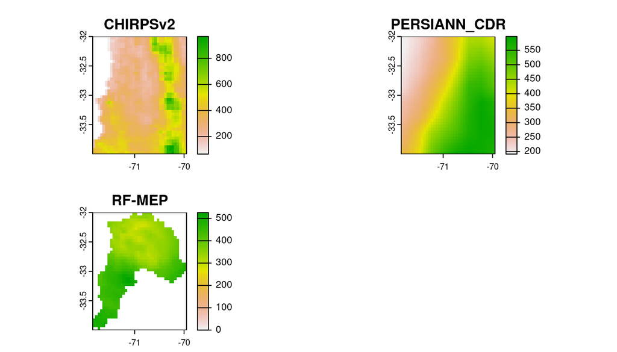

```r
rfmep_total   <- sum(rfmep, na.rm = TRUE)
totals        <- c(chirps_total, persiann_total, rfmep_total)
names(totals) <- c('CHIRPSv2', 'PERSIANN_CDR', 'RF-MEP')
plot(totals)
```

**Paso 7**: utilizaremos el conjunto de datos de evaluación de observaciones de estaciones de medición de precipitación para evaluar el rendimiento de RF-MEP con observaciones que no se utilizaron en el procedimiento de fusión.

```r
eval          <- paste0(drty_out, "/Ground_based_data/Evaluation/Evaluation_ts.txt")
metadata_eval <- paste0(drty_out, "/Ground_based_data/Evaluation/Evaluation_metadata.txt")
eval          <- read.zoo(eval, header = TRUE)
metadata_eval <- read.csv(metadata_eval)
stations_eval <- vect(metadata_eval, geom = c('lon', 'lat'), crs = 'epsg:4326')
```

Visualicemos una capa de RF-MEP junto con las estaciones de medición de precipitación y el área de estudio.

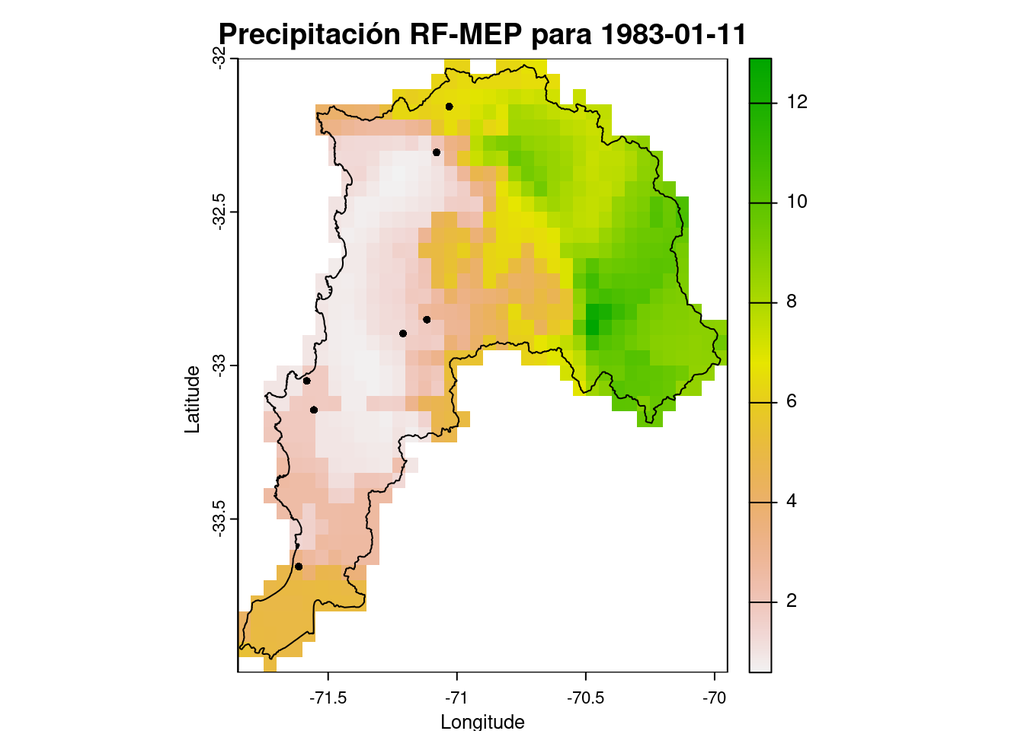

```r
plot(rfmep[[11]], main = "Precipitación RF-MEP para 1983-01-11", xlab="Longitude", ylab="Latitude")
lines(shape)
points(stations_eval, pch = 16, col="black", add = TRUE)
```

Primero, compararemos RF-MEP (y los dos productos de precipitación utilizados como covariables) con los datos de las estaciones de lluvia del conjunto de evaluación. Para extraer los valores de precipitación de RF-MEP en las ubicaciones de las estaciones, utilizaremos la función **extract** del paquete **terra**:

```r
rfmep_ts    <- t(terra::extract(rfmep, stations_eval))[-1,]
chirps_ts   <- t(terra::extract(chirps, stations_eval))[-1,]
persiann_ts <- t(terra::extract(persiann_cdr, stations_eval))[-1,]
```

Ahora realizaremos una evaluación similar a la que hicimos en el Módulo 6 para evaluar el rendimiento de los productos de precipitación:

```r
products  <- list(chirps_ts, persiann_ts, rfmep_ts)
nproducts <- length(products)
nstations <- ncol(eval)
tmp       <- rep(NA, nstations)
kges      <- data.frame(ID=stations_eval[["Code"]], CHIRPS=tmp, PERSIANN_CDR=tmp, RF_MEP=tmp)

for (i in 1:nproducts) {
  ldates        <- time(eval)
  lsim          <- zoo(products[[i]], ldates)
  kges[, (i+1)] <- hydroGOF::KGE(sim= lsim, obs= eval, method="2012")
}
```

Ahora podemos visualizar los resultados:

```r
print(kges)
```

```
##       Code    CHIRPS PERSIANN_CDR    RF_MEP
## 1 P5111002 0.2208663    0.2747440 0.8107479
## 2 P5111004 0.4347262    0.3575394 0.9356417
## 3 P5423013 0.2988270    0.3147489 0.9064508
## 4 P5426004 0.3098025    0.3046178 0.5851787
## 5 P5510001 0.2054815    0.2207958 0.8328623
## 6 P5510002 0.3214045    0.1350623 0.7404134
## 7  P330030 0.1993864    0.3521491 0.6361100
```

Finalmente, se generará un boxplot que compare el desempeño, en términos de KGE’, del producto fusionado en comparación con los productos originales utilizados como covariables.

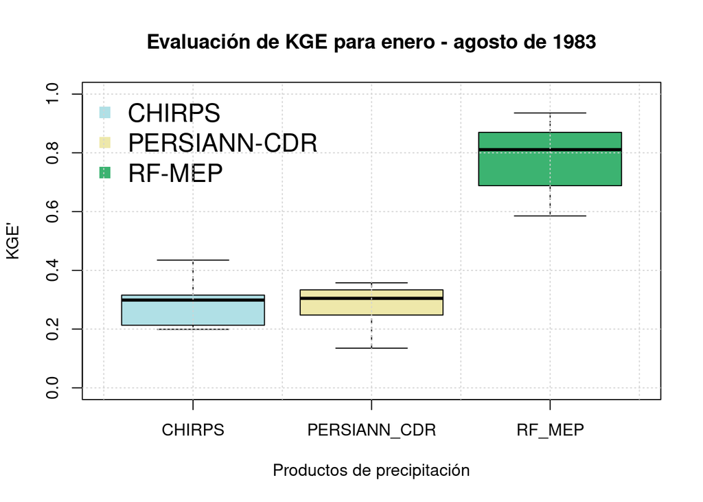

```r
sres_cols <- c("powderblue", "palegoldenrod", "mediumseagreen")
boxplot(kges[,2:4], main = "Evaluación de KGE para enero - agosto de 1983",
xlab = "Productos de precipitación", ylab = "KGE'", ylim = c(0, 1), col=sres_cols)
legend("topleft", legend=c("CHIRPS", "PERSIANN-CDR", "RF-MEP"), col=sres_cols,
pch=15, cex=1.5, bty="n")
grid()
```